# Non-Linear Mixed Effects

Carter Hogan

11/17/2024

## Empirical Distribution of Duration

First we visually inspect a series of plausible distributions for duration

```r
library(fitdistrplus)
duration <- df$duration
# Fit multiple distributions
fit_normal <- fitdist(duration, "norm")
fit_lognormal <- fitdist(duration, "lnorm")
fit_gamma <- fitdist(duration, "gamma")
fit_exponential <- fitdist(duration, "exp")

# Compare the fitted models
summary(fit_normal)
```

```
## Fitting of the distribution ' norm ' by maximum likelihood
## Parameters :
##       estimate   Std. Error
## mean 0.2556641 0.0005052396
## sd   0.1826426 0.0003572102
## Loglikelihood:  36758.42   AIC:  -73512.84   BIC:  -73493.28
## Correlation matrix:
##      mean sd
## mean    1  0
## sd      0  1
```

```r
summary(fit_lognormal)
```

```
## Fitting of the distribution ' lnorm ' by maximum likelihood
## Parameters :
##           estimate  Std. Error
## meanlog -1.5472509 0.001604833
## sdlog    0.5801423 0.001134773
## Loglikelihood:  87920.75   AIC:  -175837.5   BIC:  -175817.9
## Correlation matrix:
##              meanlog        sdlog
## meanlog 1.000000e+00 6.625204e-12
## sdlog   6.625204e-12 1.000000e+00
```

```r
summary(fit_gamma)
```

```
## Fitting of the distribution ' gamma ' by maximum likelihood
## Parameters :
##        estimate Std. Error
## shape  2.882243 0.01068757
## rate  11.273714 0.04566172
## Loglikelihood:  78448.32   AIC:  -156892.6   BIC:  -156873.1
## Correlation matrix:
##         shape    rate
## shape 1.00000 0.91551
## rate  0.91551 1.00000
```

```r
summary(fit_exponential)
```

```
## Fitting of the distribution ' exp ' by maximum likelihood
## Parameters :
##      estimate Std. Error
## rate 3.911383 0.01081996
## Loglikelihood:  47553.27   AIC:  -95104.54   BIC:  -95094.76
```

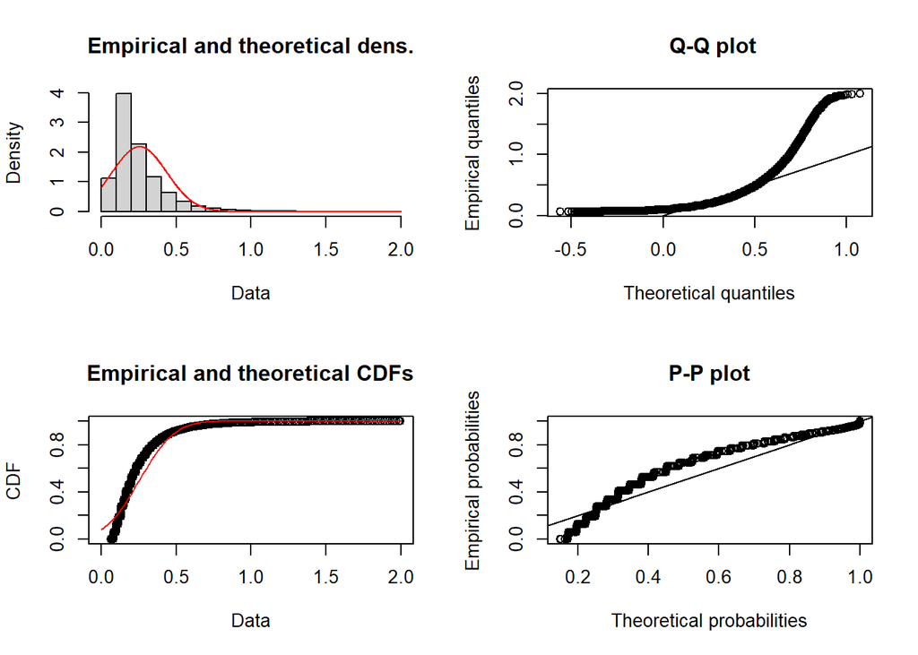

```r
# Plot the fits
plot(fit_normal)
```

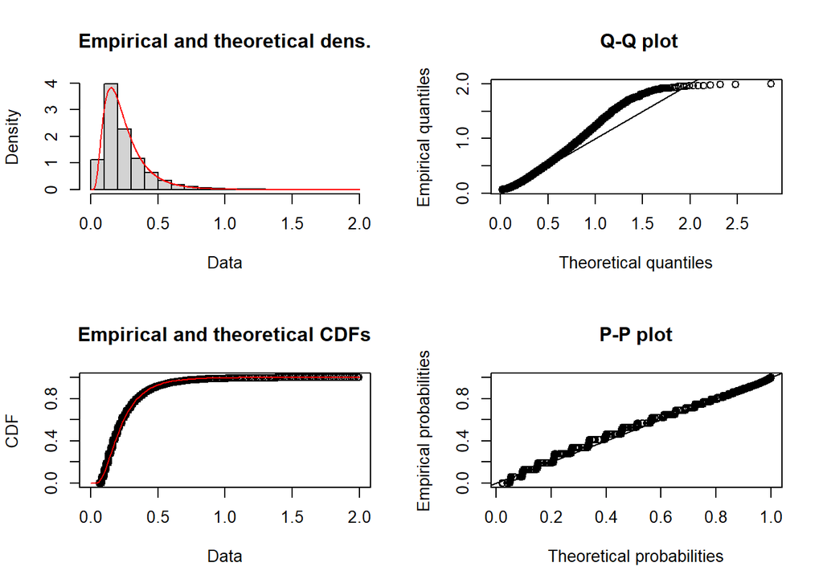

```r
plot(fit_lognormal)
```

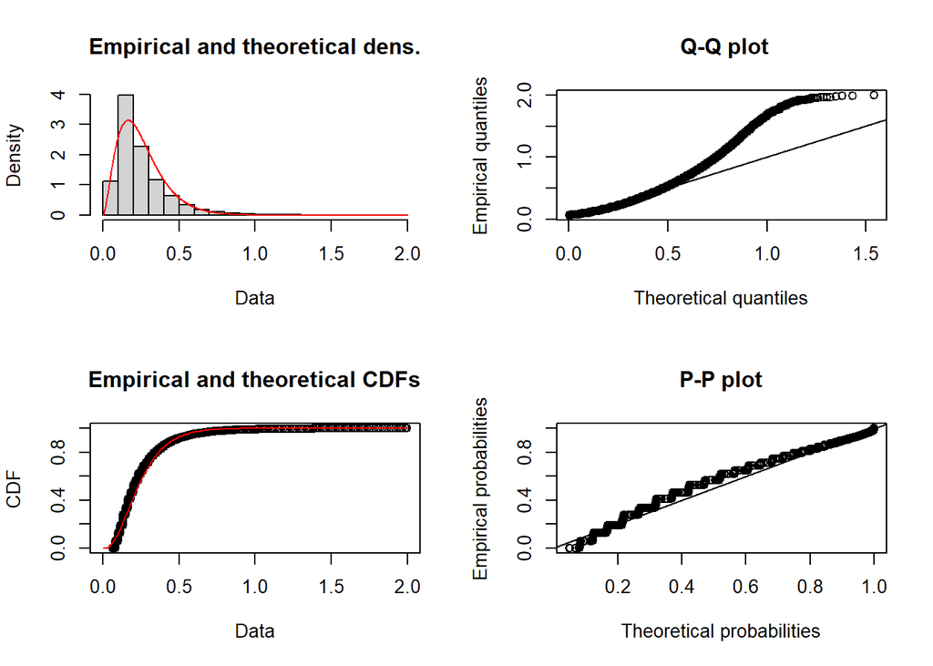

```r
plot(fit_gamma)
```

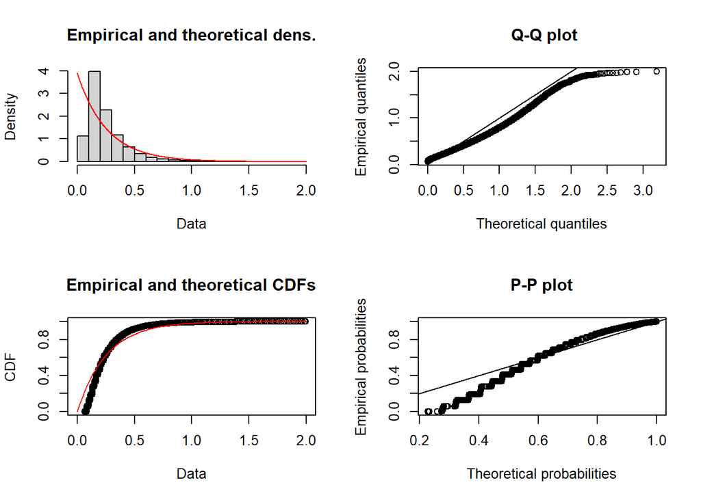

```r
plot(fit_exponential)
```

The above plots suggest that duration is log-normally distributed, or at least the most similar to a log-normal distribution

#Plot Comparisons We prepare another visual inspection comparing all plausible distributions

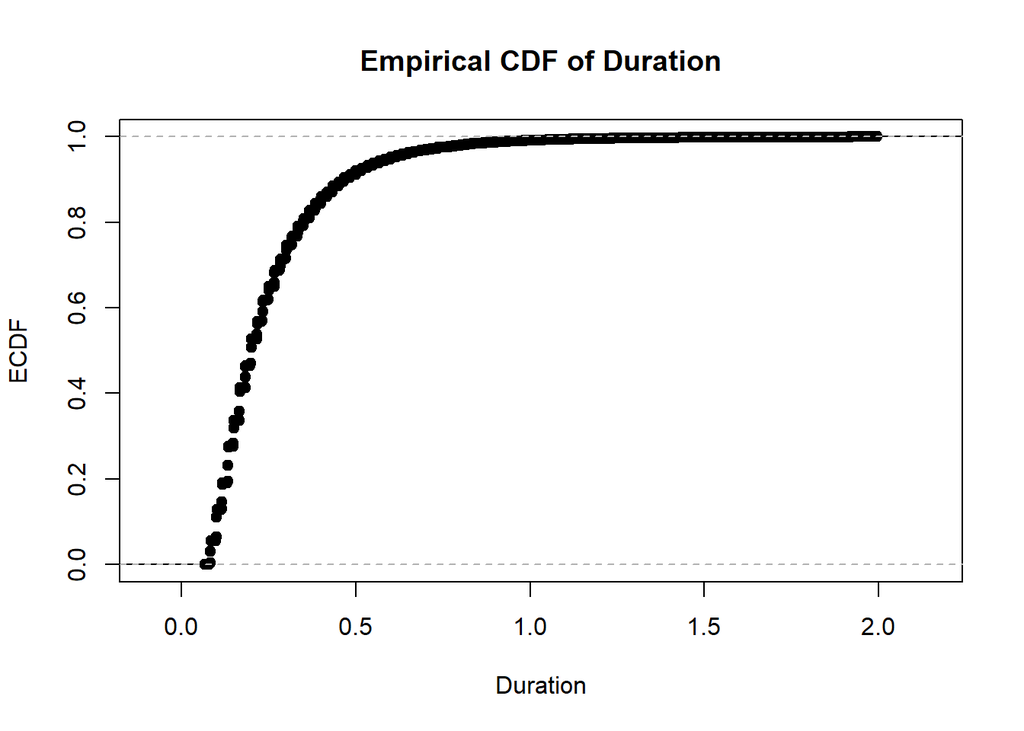

```r
# Assuming 'duration' is your data vector
ecdf_data <- ecdf(duration)

# Plot the ECDF
plot(ecdf_data, main = "Empirical CDF of Duration", xlab = "Duration", ylab = "ECDF")
```

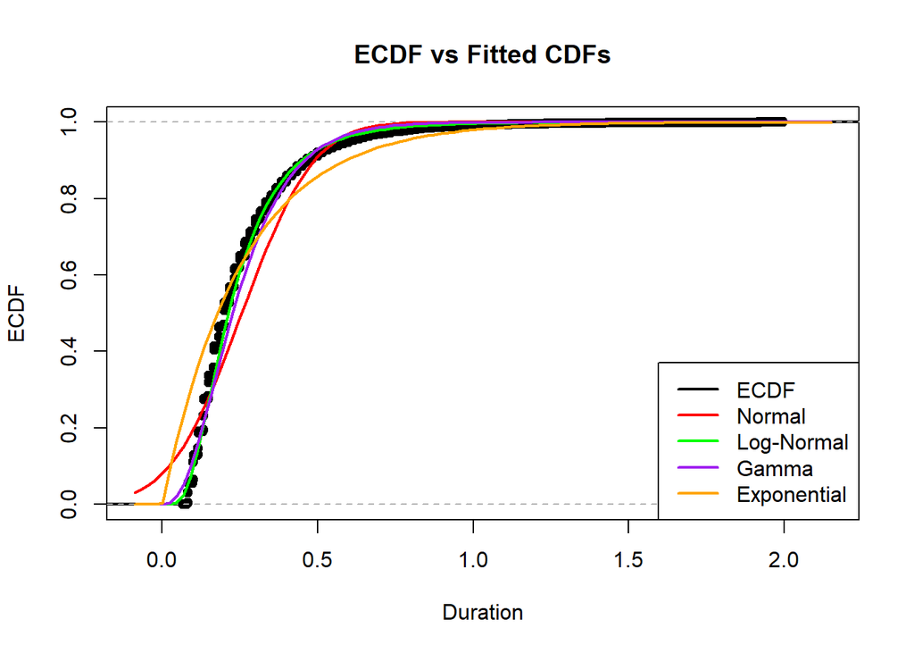

```r
# Plot ECDF
plot(ecdf_data, main = "ECDF vs Fitted CDFs", xlab = "Duration", ylab = "ECDF", col = "black", lwd = 2)

# Add the fitted CDFs to the ECDF plot
curve(pnorm(x, mean = fit_normal$estimate[1], sd = fit_normal$estimate[2]),
      col = "red", lwd = 2, add = TRUE)
curve(plnorm(x, meanlog = fit_lognormal$estimate[1], sdlog = fit_lognormal$estimate[2]),
      col = "green", lwd = 2, add = TRUE)
curve(pgamma(x, shape = fit_gamma$estimate[1], rate = fit_gamma$estimate[2]),
      col = "purple", lwd = 2, add = TRUE)
curve(pexp(x, rate = fit_exponential$estimate[1]),
      col = "orange", lwd = 2, add = TRUE)

# Add a legend to label the lines
legend("bottomright",
       legend = c("ECDF", "Normal", "Log-Normal", "Gamma", "Exponential"),
       col = c("black", "red", "green", "purple", "orange"),
       lwd = 2)
```

This reaffirms that duration appears to be log-normally distributed # Goodness of fit

```r
# Kolmogorov-Smirnov test for log-normality
log_mean <- mean(log(duration))  # Mean of the log-transformed data
log_sd <- sd(log(duration))      # Standard deviation of the log-transformed data

ks_test_log_normal <- ks.test(duration, "plnorm", meanlog = log_mean, sdlog = log_sd)
print(ks_test_log_normal)
```

```
##
##  Asymptotic one-sample Kolmogorov-Smirnov test
##
## data:  duration
## D = 0.07144, p-value < 2.2e-16
## alternative hypothesis: two-sided
```

```r
# Anderson-Darling test for log-normality
library(nortest)
ad_test_log_normal <- ad.test(log(duration))  # Apply AD test to the log-transformed data
print(ad_test_log_normal)
```

```
##
##  Anderson-Darling normality test
##
## data:  log(duration)
## A = 694.4, p-value < 2.2e-16
```

The statistical tests do not validate this hypothesis, however we use this as the best practical fit for the data because of the visual match

# First we run a simple linear model for better initial values

```r
# Fit linear model (this approximates the nonlinear relationship)
linear_model <- lm(log_duration ~ Order_log, data = df)

# Use the coefficients of the linear model as starting values
a_start <- coef(linear_model)[1]  # Intercept
b_start <- -coef(linear_model)[2]  # Negative slope for decay model

# Print the estimated starting values
cat("Initial values: a =", a_start, "b =", b_start, "\n")
```

```
## Initial values: a = -1.642777 b = -0.04070717
```

## Non-linear Mixed Effects Model (simple)

We decided to use a logarithmic decay function for Order based on the scatter plots of the relationship between Order and Fixation Duration outlined in our EDA

```r
model_simple <- nlme(
  log_duration ~ a - b * Order_log,
  fixed = a + b ~ ~1,            # Intercept-only fixed effects
  random = a + b ~ 1 | ID,
  start = c(a_intercept = -1.642777,            # Initial value for a's intercept
            b_intercept = -0.04070717),
  data = df
)

summary(model_simple)
```

```
## Nonlinear mixed-effects model fit by maximum likelihood
##   Model: log_duration ~ a - b * Order_log
##   Data: df
##        AIC      BIC    logLik
##   226587.1 226645.7 -113287.5
##
## Random effects:
##  Formula: list(a ~ 1, b ~ 1)
##  Level: ID
##  Structure: General positive-definite, Log-Cholesky parametrization
##               StdDev     Corr
## a.(Intercept) 0.15538721 a.(In)
## b.(Intercept) 0.02991363 0.705
## Residual      0.56705206
##
## Fixed effects:  a + b ~ ~1
##                    Value   Std.Error     DF   t-value p-value
## a.(Intercept) -1.6612233 0.005162705 125485 -321.7738       0
## b.(Intercept) -0.0526516 0.001937617 125485  -27.1734       0
##  Correlation:
##               a.(In)
## b.(Intercept) 0.899
##
## Standardized Within-Group Residuals:
##         Min          Q1         Med          Q3         Max
## -2.35215211 -0.74244600 -0.08997137  0.65740040  4.09846891
##
## Number of Observations: 130680
## Number of Groups: 5194
```

From the output above, we find that the parameters a and b are both statistically significant, this model suggests that the baseline duration is -1.6612233 and the decay rate is -0.0526516 We evaluate a more complex model to ensure that all variables have been properly accounted for.

## Non-linear Mixed Effects Model (Age and Gender)

Now using age and gender as fixed effects we re-estimate the NLME model.

```r
model_age_gender <- nlme(
  log_duration ~ a - b * Order_log,
  fixed = a + b ~ age +female,            # Intercept-only fixed effects
  random = a + b ~ 1 | ID,
  start = c(a_intercept = -1.642777,            # Initial value for a's intercept
            b_intercept = -0.04070717,             # Initial value for b's intercept
            a_age = 0,                    # Initial value for age effect on a
            b_age = 0,                    # Initial value for age effect on b
            a_female = 0,                 # Initial value for female effect on a
            b_female = 0),
  data = df
)

summary(model_age_gender)
```

```
## Nonlinear mixed-effects model fit by maximum likelihood
##   Model: log_duration ~ a - b * Order_log
##   Data: df
##        AIC    BIC    logLik
##   226590.1 226688 -113285.1
##
## Random effects:
##  Formula: list(a ~ 1, b ~ 1)
##  Level: ID
##  Structure: General positive-definite, Log-Cholesky parametrization
##               StdDev     Corr
## a.(Intercept) 0.15545401 a.(In)
## b.(Intercept) 0.02995189 0.707
## Residual      0.56704664
##
## Fixed effects:  a + b ~ age + female
##                    Value   Std.Error     DF    t-value p-value
## a.(Intercept) -1.6589020 0.014868442 125481 -111.57202  0.0000
## a.age         -0.0000386 0.000436941 125481   -0.08841  0.9295
## a.female      -0.0025936 0.010396764 125481   -0.24946  0.8030
## b.(Intercept) -0.0532126 0.005596717 125481   -9.50783  0.0000
## b.age          0.0000773 0.000164297 125481    0.47023  0.6382
## b.female      -0.0039125 0.003900977 125481   -1.00294  0.3159
##  Correlation:
##               a.(In) a.age  a.feml b.(In) b.age
## a.age         -0.885
## a.female      -0.330  0.023
## b.(Intercept)  0.898 -0.795 -0.296
## b.age         -0.796  0.899  0.021 -0.886
## b.female      -0.297  0.021  0.899 -0.331  0.024
##
## Standardized Within-Group Residuals:
##         Min          Q1         Med          Q3         Max
## -2.35436484 -0.74210793 -0.08987782  0.65758713  4.08575252
##
## Number of Observations: 130680
## Number of Groups: 5194
```

## Non-linear Mixed Effects Model (Age, Gender and ROI)

Using now the ROI_area metric that accounts for the size of the ROI belonging to each fixation, we re-estimate the NLME model.

```r
model_roi <- nlme(
  log_duration ~ a - b * Order_log,
  fixed = a + b ~ age +female + ROI_area,            # Intercept-only fixed effects
  random = a + b ~ 1 | ID,
  start = c(a_intercept = -1.642777,            # Initial value for a's intercept
            b_intercept = -0.04070717,             # Initial value for b's intercept
            a_age = 0,                    # Initial value for age effect on a
            b_age = 0,                    # Initial value for age effect on b
            a_female = 0,                 # Initial value for female effect on a
            b_female = 0,
            a_roi_area = 0,
            b_roi_area = 0),
  data = df
)

summary(model_roi)
```

```
## Nonlinear mixed-effects model fit by maximum likelihood
##   Model: log_duration ~ a - b * Order_log
##   Data: df
##        AIC    BIC    logLik
##   226532.7 226650 -113254.3
##
## Random effects:
##  Formula: list(a ~ 1, b ~ 1)
##  Level: ID
##  Structure: General positive-definite, Log-Cholesky parametrization
##               StdDev     Corr
## a.(Intercept) 0.15580144 a.(In)
## b.(Intercept) 0.03022959 0.708
## Residual      0.56690858
##
## Fixed effects:  a + b ~ age + female + ROI_area
##                    Value   Std.Error     DF    t-value p-value
## a.(Intercept) -1.6584428 0.014875450 125479 -111.48858  0.0000
## a.age         -0.0000346 0.000437152 125479   -0.07912  0.9369
## a.female      -0.0026989 0.010398886 125479   -0.25954  0.7952
## a.ROI_area     0.0026460 0.005401808 125479    0.48984  0.6242
## b.(Intercept) -0.0526158 0.005599736 125479   -9.39612  0.0000
## b.age          0.0000685 0.000164383 125479    0.41680  0.6768
## b.female      -0.0039985 0.003901817 125479   -1.02477  0.3055
## b.ROI_area    -0.0039608 0.002115560 125479   -1.87221  0.0612
##  Correlation:
##               a.(In) a.age  a.feml a.ROI_ b.(In) b.age  b.feml
## a.age         -0.884
## a.female      -0.330  0.023
## a.ROI_area     0.023  0.024 -0.003
## b.(Intercept)  0.898 -0.794 -0.296  0.023
## b.age         -0.795  0.899  0.021  0.024 -0.885
## b.female      -0.297  0.021  0.899 -0.003 -0.331  0.024
## b.ROI_area     0.022  0.023 -0.002  0.954  0.018  0.025 -0.002
##
## Standardized Within-Group Residuals:
##         Min          Q1         Med          Q3         Max
## -2.33834761 -0.74192588 -0.08958977  0.65746686  4.07102163
##
## Number of Observations: 130680
## Number of Groups: 5194
```

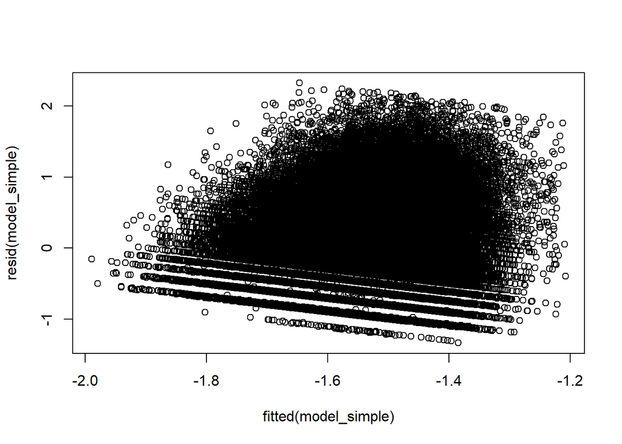

```r
# Simple plot of residuals vs. predicted values
plot(fitted(model_simple), resid(model_simple))
```

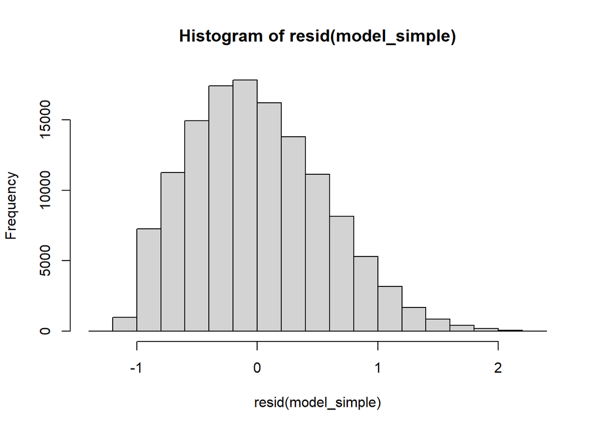

```r
# Histogram of Residuals
hist(resid(model_simple))
```

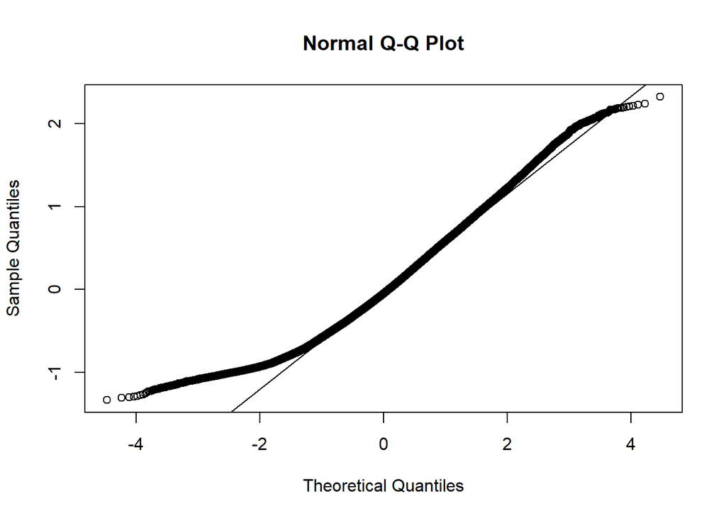

```r
# QQ plot
qqnorm(resid(model_simple))
qqline(resid(model_simple))
```

We notice that the residuals show signs of heteroscedasticity and we add a variance function to the analysis to fix this. The Histogram appears to be normally distributed with a minor skewness right. The QQ- plot also suggest that the residuals are roughly normal with minor skewness on the left tail.

# Adjustments for Heteroscedasticity (Parallelized Approach Split on Age Cluster)

```r
library(foreach)
library(doParallel)
num_cores <- detectCores() - 1  # Use one less than the number of cores
cl <- makeCluster(num_cores)  # Create a cluster with the desired number of cores
registerDoParallel(cl)
df_clean <- na.omit(df[, c("log_duration", "Order_log", "ID", "Age_Group_Cluster")])
# Assuming your data is divided into multiple subsets for parallel fitting
```

```r
subsets <- split(df_clean, df_clean$Age_Group_Cluster)  # Split data by region, or any other grouping factor

# Parallelize model fitting using foreach
results <- foreach(subset = subsets, .packages = c("nlme")) %dopar% {
  model <- nlme(
    log_duration ~ a - b * Order_log,
    fixed = a + b ~ 1,
    random = a + b ~ 1 | ID,
    start = c(a_intercept = -1.642777,            # Initial value for a's intercept
            b_intercept = -0.04070717),
    data = subset,
    weights = varPower(),
    control = nlmeControl(maxIter = 200, msMaxIter = 200)
  )
  return(model)
}
```

```r
summary(results[[1]])
```

```
## Nonlinear mixed-effects model fit by maximum likelihood
##   Model: log_duration ~ a - b * Order_log
##   Data: subset
##        AIC      BIC    logLik
##   69738.87 69799.15 -34862.44
##
## Random effects:
##  Formula: list(a ~ 1, b ~ 1)
##  Level: ID
##  Structure: General positive-definite, Log-Cholesky parametrization
##          StdDev     Corr
## a        0.18908954 a
## b        0.04971278 0.869
## Residual 1.32493924
##
## Variance function:
##  Structure: Power of variance covariate
##  Formula: ~fitted(.)
##  Parameter estimates:
##     power
## -1.933044
## Fixed effects:  a + b ~ 1
##        Value   Std.Error    DF    t-value p-value
## a -1.6943315 0.008870832 38942 -191.00029       0
## b -0.0603581 0.003352287 38942  -18.00504       0
##  Correlation:
##   a
## b 0.9
##
## Standardized Within-Group Residuals:
##         Min          Q1         Med          Q3         Max
## -2.12504958 -0.75169912 -0.06722044  0.68842263  4.38893456
##
## Number of Observations: 40556
## Number of Groups: 1613
```

```r
summary(results[[2]])
```

```
## Nonlinear mixed-effects model fit by maximum likelihood
##   Model: log_duration ~ a - b * Order_log
##   Data: subset
##        AIC      BIC    logLik
##   52402.76 52461.12 -26194.38
##
## Random effects:
##  Formula: list(a ~ 1, b ~ 1)
##  Level: ID
##  Structure: General positive-definite, Log-Cholesky parametrization
##          StdDev     Corr
## a        0.19969680 a
## b        0.05390523 0.823
## Residual 1.19638085
##
## Variance function:
##  Structure: Power of variance covariate
##  Formula: ~fitted(.)
##  Parameter estimates:
##     power
## -1.725065
## Fixed effects:  a + b ~ 1
##        Value   Std.Error    DF    t-value p-value
## a -1.7010310 0.010345397 29639 -164.42395       0
## b -0.0622345 0.003873244 29639  -16.06781       0
##  Correlation:
##   a
## b 0.89
##
## Standardized Within-Group Residuals:
##         Min          Q1         Med          Q3         Max
## -2.09720650 -0.73316899 -0.05834796  0.69203961  4.14541259
##
## Number of Observations: 30854
## Number of Groups: 1214
```

```r
summary(results[[3]])
```

```
## Nonlinear mixed-effects model fit by maximum likelihood
##   Model: log_duration ~ a - b * Order_log
##   Data: subset
##        AIC      BIC    logLik
##   41704.33 41760.97 -20845.16
##
## Random effects:
##  Formula: list(a ~ 1, b ~ 1)
##  Level: ID
##  Structure: General positive-definite, Log-Cholesky parametrization
##          StdDev     Corr
## a        0.18588260 a
## b        0.03989254 0.869
## Residual 1.25223438
##
## Variance function:
##  Structure: Power of variance covariate
##  Formula: ~fitted(.)
##  Parameter estimates:
##     power
## -1.789488
## Fixed effects:  a + b ~ 1
##        Value   Std.Error    DF    t-value p-value
## a -1.6964597 0.011534304 23188 -147.07950       0
## b -0.0601834 0.004258792 23188  -14.13156       0
##  Correlation:
##   a
## b 0.892
##
## Standardized Within-Group Residuals:
##         Min          Q1         Med          Q3         Max
## -2.08870015 -0.73723766 -0.06894018  0.69133891  4.04543935
##
## Number of Observations: 24146
## Number of Groups: 957
```

```r
summary(results[[4]])
```

```
## Nonlinear mixed-effects model fit by maximum likelihood
##   Model: log_duration ~ a - b * Order_log
##   Data: subset
##        AIC      BIC    logLik
##   27742.88 27796.78 -13864.44
##
## Random effects:
##  Formula: list(a ~ 1, b ~ 1)
##  Level: ID
##  Structure: General positive-definite, Log-Cholesky parametrization
##          StdDev     Corr
## a        0.17682695 a
## b        0.05404357 0.804
## Residual 1.23965862
##
## Variance function:
##  Structure: Power of variance covariate
##  Formula: ~fitted(.)
##  Parameter estimates:
##     power
## -1.778832
## Fixed effects:  a + b ~ 1
##       Value   Std.Error    DF    t-value p-value
## a -1.696234 0.013818160 15667 -122.75396       0
## b -0.056618 0.005380265 15667  -10.52327       0
##  Correlation:
##   a
## b 0.898
##
## Standardized Within-Group Residuals:
##         Min          Q1         Med          Q3         Max
## -2.11332288 -0.74174527 -0.05155694  0.69354994  4.11955652
##
## Number of Observations: 16316
## Number of Groups: 648
```

```r
summary(results[[5]])
```

```
## Nonlinear mixed-effects model fit by maximum likelihood
##   Model: log_duration ~ a - b * Order_log
##   Data: subset
##        AIC      BIC    logLik
##   32533.15 32588.04 -16259.57
##
## Random effects:
##  Formula: list(a ~ 1, b ~ 1)
##  Level: ID
##  Structure: General positive-definite, Log-Cholesky parametrization
##          StdDev     Corr
## a        0.20841115 a
## b        0.07293076 0.831
## Residual 1.28637708
##
## Variance function:
##  Structure: Power of variance covariate
##  Formula: ~fitted(.)
##  Parameter estimates:
##     power
## -1.835202
## Fixed effects:  a + b ~ 1
##        Value   Std.Error    DF    t-value p-value
## a -1.7180421 0.013360500 18045 -128.59115       0
## b -0.0669323 0.005328252 18045  -12.56177       0
##  Correlation:
##   a
## b 0.896
##
## Standardized Within-Group Residuals:
##         Min          Q1         Med          Q3         Max
## -2.09947798 -0.72322692 -0.05501801  0.65778541  4.63570289
##
## Number of Observations: 18808
## Number of Groups: 762
```

# Model 1

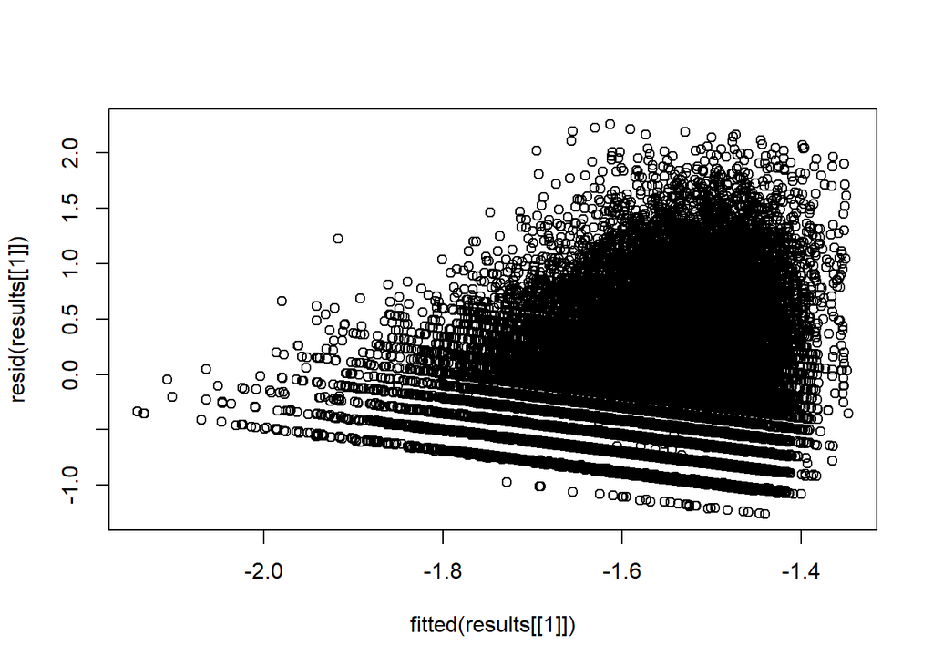

```r
# Model 1
# Simple plot of residuals vs. predicted values
plot(fitted(results[[1]]), resid(results[[1]]))
```

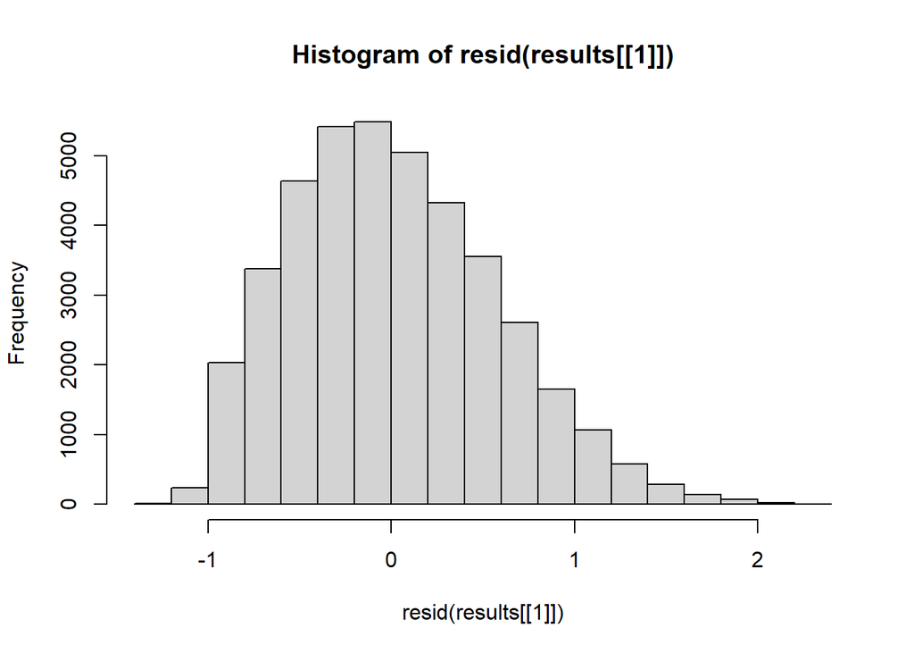

```r
# Histogram of Residuals
hist(resid(results[[1]]))
```

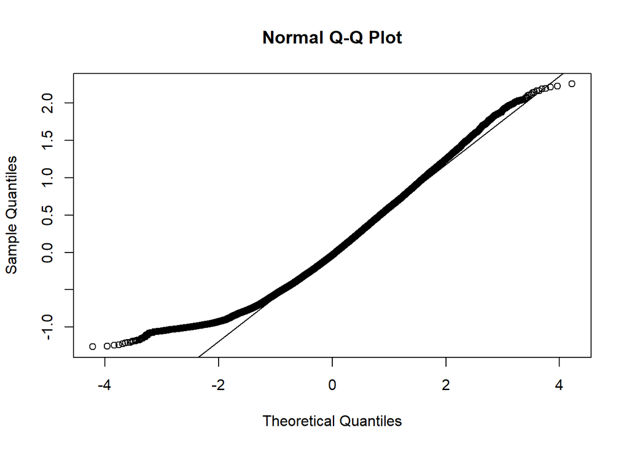

```r
# QQ plot
qqnorm(resid(results[[1]]))
qqline(resid(results[[1]]))
```

# Model 2

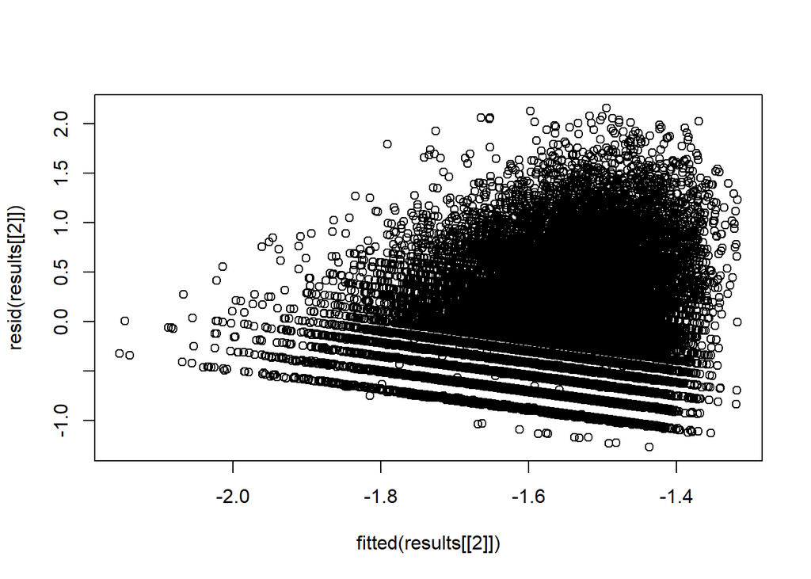

```r
# Model 1
# Simple plot of residuals vs. predicted values
plot(fitted(results[[2]]), resid(results[[2]]))
```

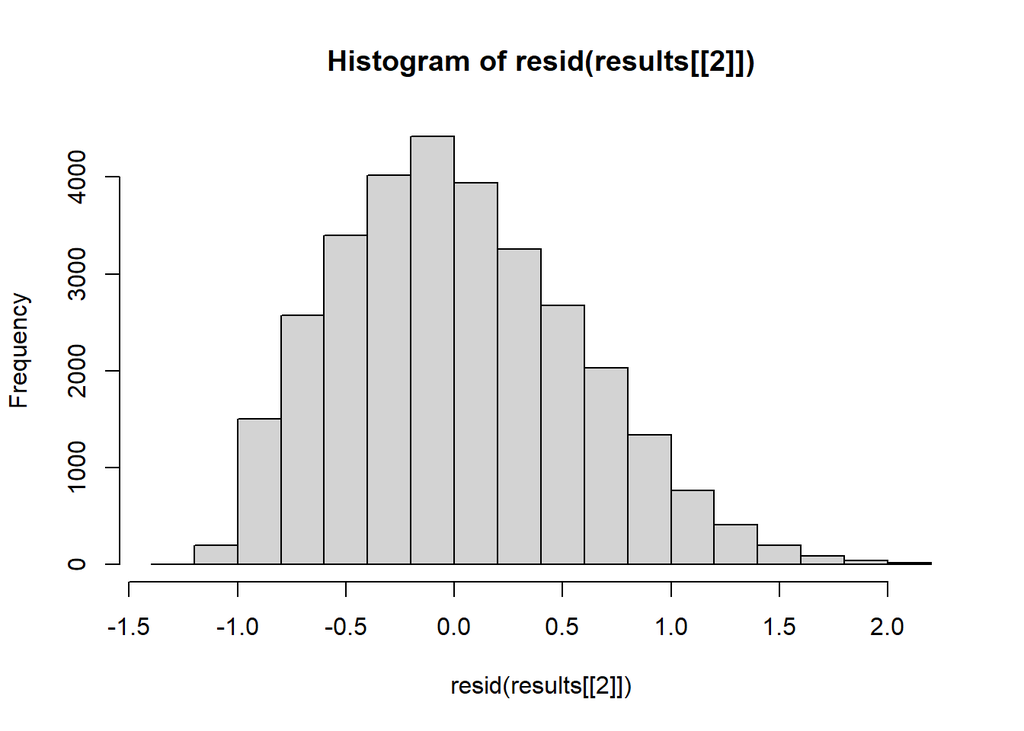

```r
# Histogram of Residuals
hist(resid(results[[2]]))
```

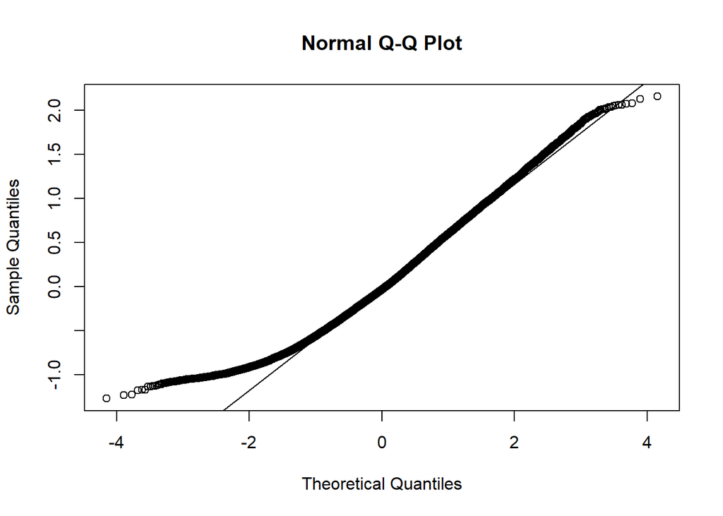

```r
# QQ plot
qqnorm(resid(results[[2]]))
qqline(resid(results[[2]]))
```

# Model 3

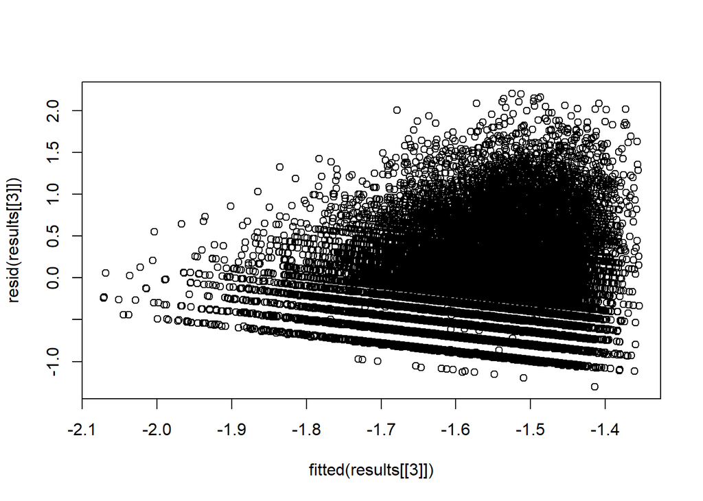

```r
# Model 1
# Simple plot of residuals vs. predicted values
plot(fitted(results[[3]]), resid(results[[3]]))
```

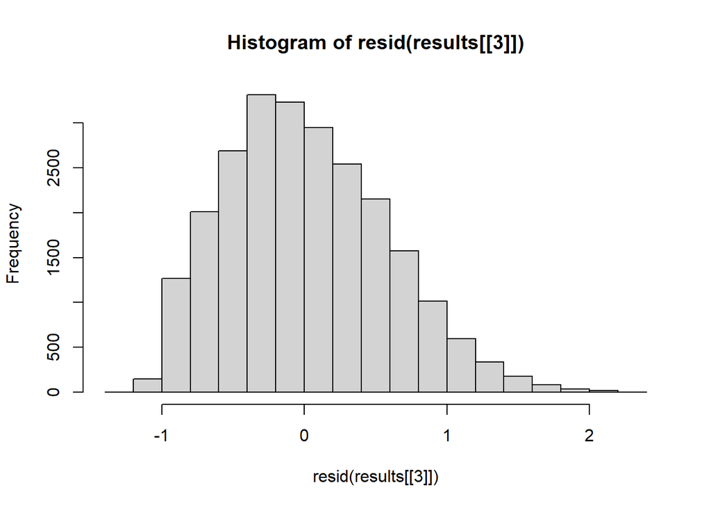

```r
# Histogram of Residuals
hist(resid(results[[3]]))
```

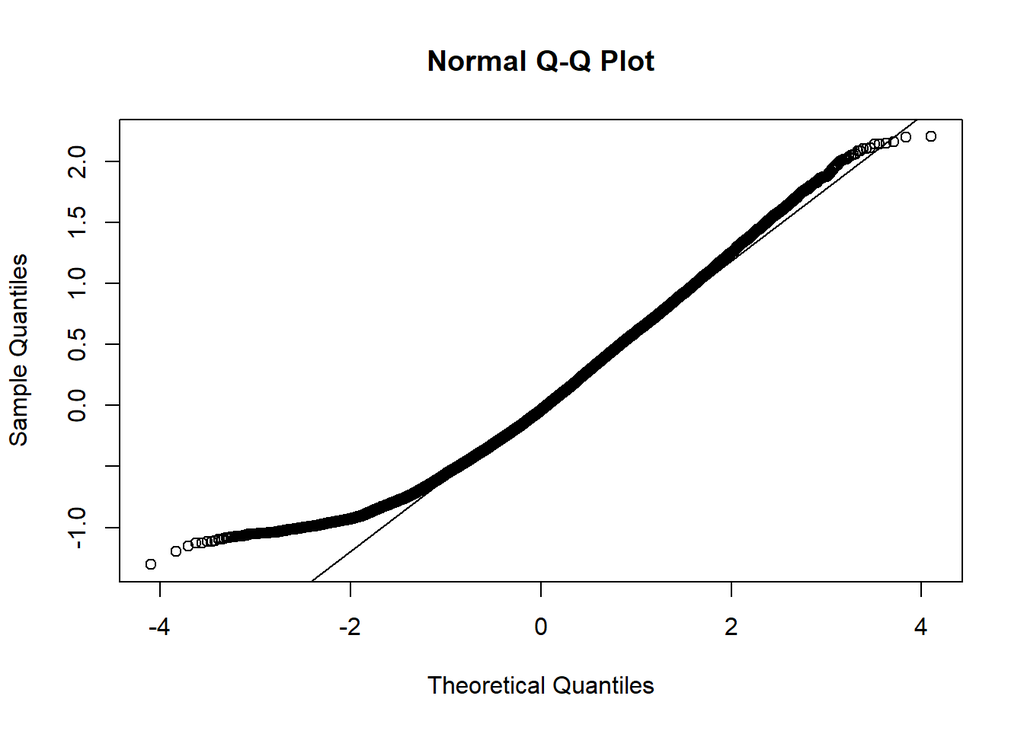

```r
# QQ plot
qqnorm(resid(results[[3]]))
qqline(resid(results[[3]]))
```

# Model 4

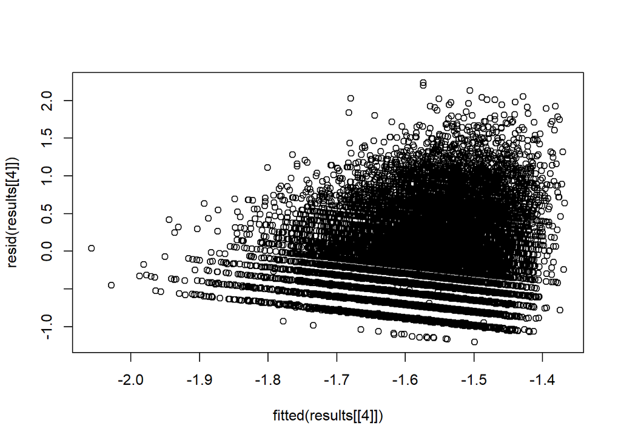

```r
# Model 1
# Simple plot of residuals vs. predicted values
plot(fitted(results[[4]]), resid(results[[4]]))
```

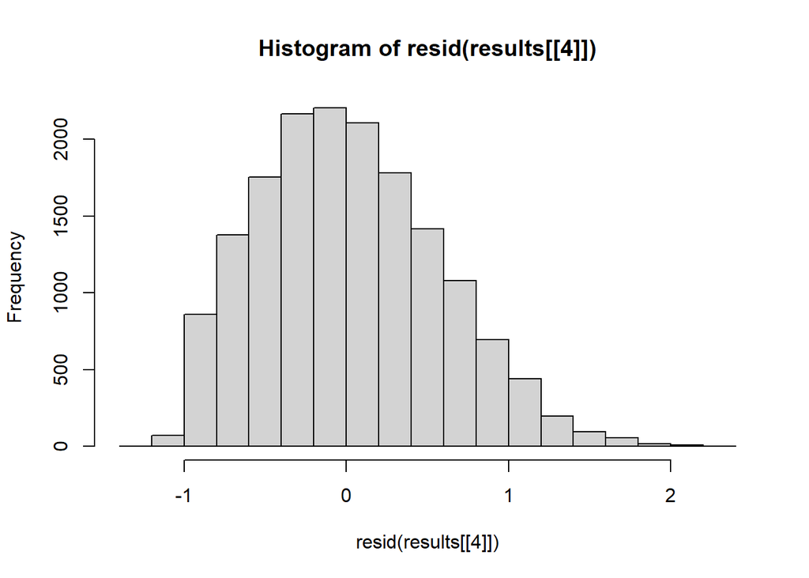

```r
# Histogram of Residuals
hist(resid(results[[4]]))
```

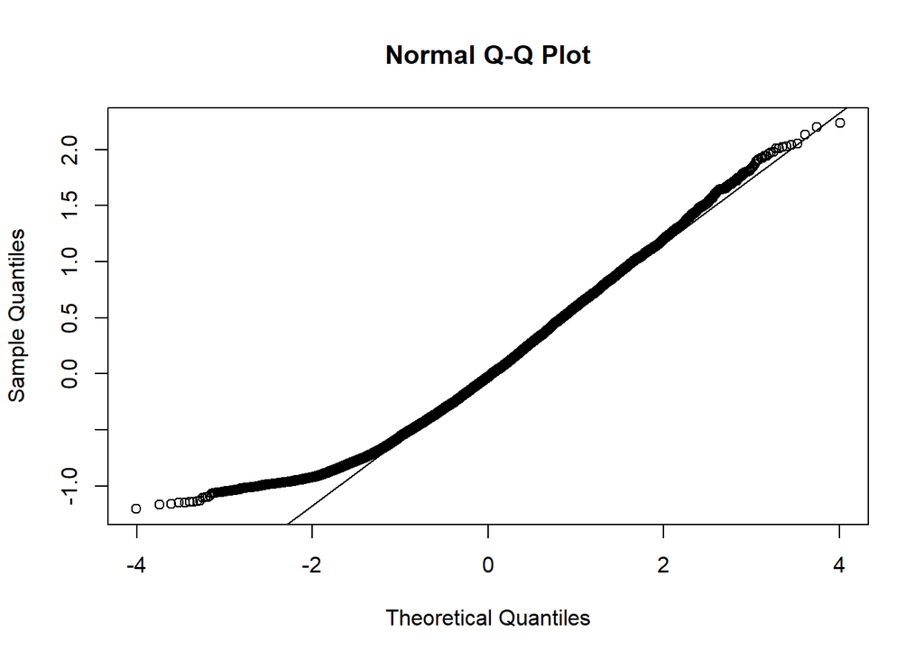

```r
# QQ plot
qqnorm(resid(results[[4]]))
qqline(resid(results[[4]]))
```

# Model 5

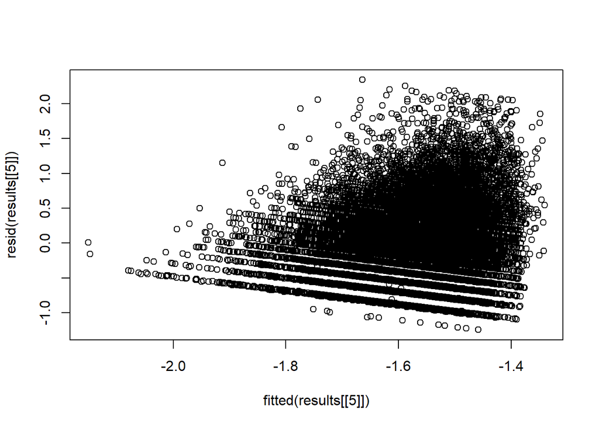

```r
# Model 1
# Simple plot of residuals vs. predicted values
plot(fitted(results[[5]]), resid(results[[5]]))
```

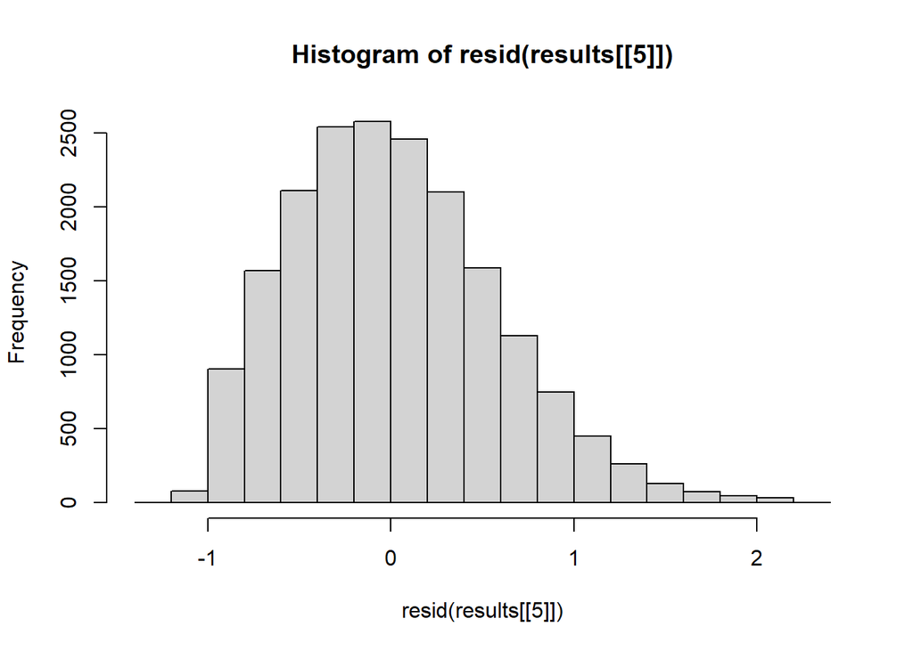

```r
# Histogram of Residuals
hist(resid(results[[5]]))
```

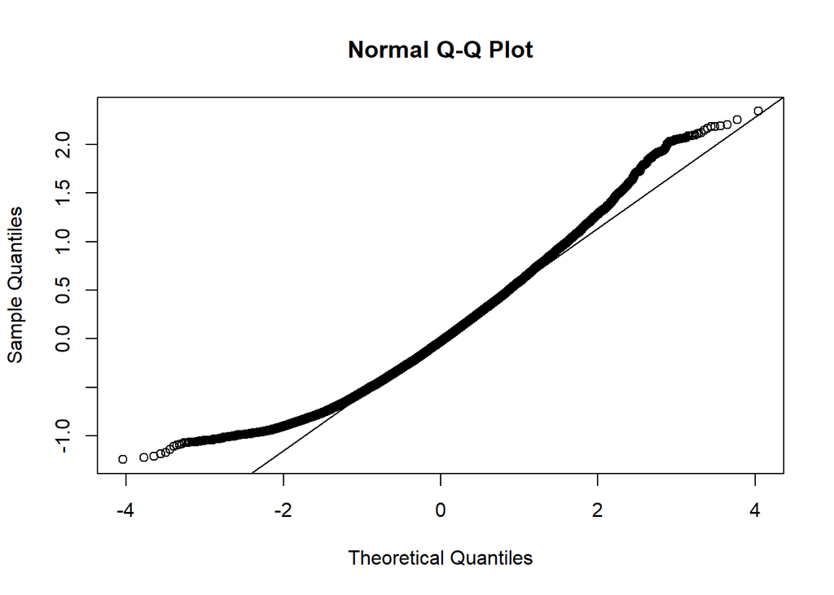

```r
# QQ plot
qqnorm(resid(results[[5]]))
qqline(resid(results[[5]]))
```

we see that adjusting for the variance did not change the QQ-Plots at all and the estimates are roughly the same. We attempt first to try the simple model with other covariates to see if this can eliminate the problem

```r
model_cov <- nlme(
  log_duration ~ a - b * Order_log +Age_18.26 + Age_27.35 + Age_36.45 + Age_46.59 + ROI_area + female,
  fixed = a + b ~ Age_18.26 + Age_27.35 + Age_36.45 + Age_46.59 + ROI_area +female,            # Intercept-only fixed effects
  random = a + b ~ 1 | ID,
  start = c(a_intercept = -1.642777,            # Initial value for a's intercept
            b_intercept = -0.040707,
            a_1 = 0,
            b_1 = 0,
            a_2 = 0,
            b_2 = 0,
            a_3 = 0,
            b_3 = 0,
            a_4 = 0,
            b_4 = 0,
            a_ROI = 0,
            b_ROI = 0,
            a_f =0,
            b_f = 0),
  data = df
)

summary(model_cov)
```

```
## Nonlinear mixed-effects model fit by maximum likelihood
##   Model: log_duration ~ a - b * Order_log + Age_18.26 + Age_27.35 + Age_36.45 +      Age_46.59 + ROI_area + female
##   Data: df
##      AIC    BIC    logLik
##   226543 226719 -113253.5
##
## Random effects:
##  Formula: list(a ~ 1, b ~ 1)
##  Level: ID
##  Structure: General positive-definite, Log-Cholesky parametrization
##               StdDev     Corr
## a.(Intercept) 0.15563596 a.(In)
## b.(Intercept) 0.03011532 0.708
## Residual      0.56691122
##
## Fixed effects:  a + b ~ Age_18.26 + Age_27.35 + Age_36.45 + Age_46.59 + ROI_area +      female
##                    Value   Std.Error     DF    t-value p-value
## a.(Intercept) -1.6653571 0.014225226 125473 -117.07069  0.0000
## a.Age_18.26   -0.9868933 0.016401045 125473  -60.17258  0.0000
## a.Age_27.35   -0.9966850 0.017233853 125473  -57.83298  0.0000
## a.Age_36.45   -0.9955606 0.018109485 125473  -54.97454  0.0000
## a.Age_46.59   -0.9974898 0.019930432 125473  -50.04858  0.0000
## a.ROI_area    -0.9974297 0.005402566 125473 -184.62149  0.0000
## a.female      -1.0028622 0.010417223 125473  -96.26963  0.0000
## b.(Intercept) -0.0516624 0.005373790 125473   -9.61378  0.0000
## b.Age_18.26    0.0024648 0.006179576 125473    0.39887  0.6900
## b.Age_27.35   -0.0003759 0.006481858 125473   -0.05799  0.9538
## b.Age_36.45    0.0004653 0.006816785 125473    0.06826  0.9456
## b.Age_46.59    0.0026770 0.007501705 125473    0.35685  0.7212
## b.ROI_area    -0.0039949 0.002115878 125473   -1.88806  0.0590
## b.female      -0.0039694 0.003907854 125473   -1.01575  0.3097
##  Correlation:
##               a.(In) a.A_18 a.A_27 a.A_36 a.A_46 a.ROI_ a.feml b.(In) b.A_18
## a.Age_18.26   -0.779
## a.Age_27.35   -0.736  0.648
## a.Age_36.45   -0.702  0.617  0.588
## a.Age_46.59   -0.653  0.560  0.532  0.507
## a.ROI_area     0.029  0.009  0.022  0.023  0.016
## a.female      -0.308 -0.016 -0.033 -0.026  0.026 -0.004
## b.(Intercept)  0.898 -0.700 -0.661 -0.630 -0.586  0.028 -0.277
```

[output cut: 12 more lines]

```
## a.female
## b.(Intercept)
## b.Age_18.26
## b.Age_27.35
## b.Age_36.45    0.591
## b.Age_46.59    0.536  0.510
## b.ROI_area     0.023  0.026  0.017
## b.female      -0.029 -0.022  0.028 -0.003
##
## Standardized Within-Group Residuals:
##         Min          Q1         Med          Q3         Max
## -2.34093179 -0.74192968 -0.08961985  0.65722545  4.07988069
##
## Number of Observations: 130680
## Number of Groups: 5194
```

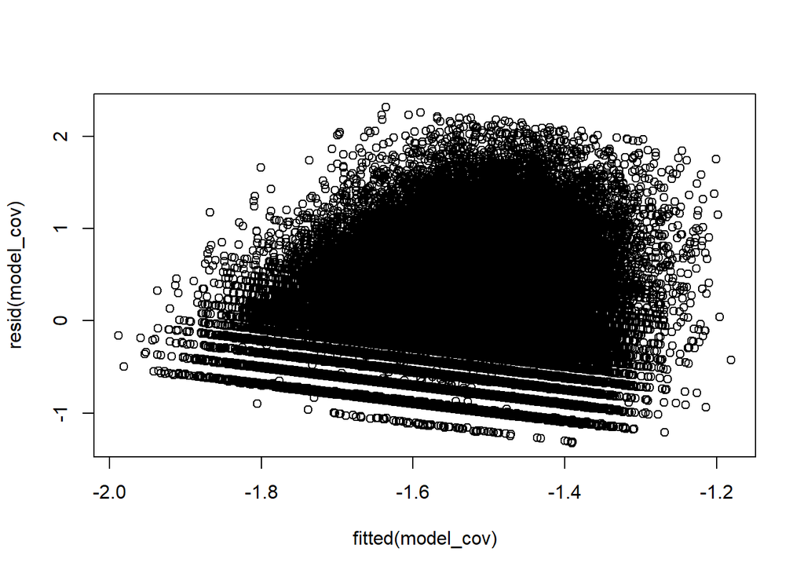

```r
# Simple plot of residuals vs. predicted values
plot(fitted(model_cov), resid(model_cov))
```

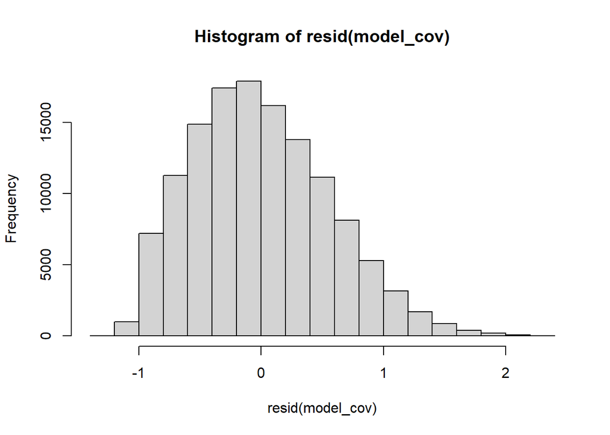

```r
# Histogram of Residuals
hist(resid(model_cov))
```

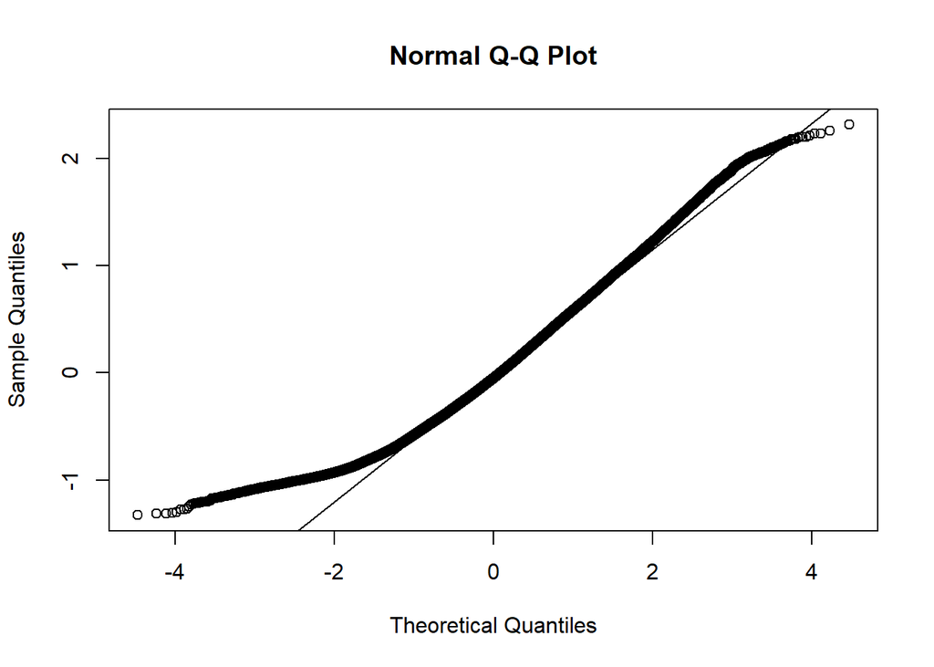

```r
# QQ plot
qqnorm(resid(model_cov))
qqline(resid(model_cov))
```

# This has also done nothing for our normality assumptions and we must consider that the model is misspecified

```r
model <-lme(log_duration ~ Order + I(Order^2) +
            log(age) +ROI_area +female, random = ~1 | ID, data = df)

summary(model)
```

```
## Linear mixed-effects model fit by REML
##   Data: df
##        AIC      BIC    logLik
##   226591.1 226669.3 -113287.5
##
## Random effects:
##  Formula: ~1 | ID
##         (Intercept)  Residual
## StdDev:    0.113433 0.5677819
##
## Fixed effects:  log_duration ~ Order + I(Order^2) + log(age) + ROI_area + female
##                  Value   Std.Error     DF   t-value p-value
## (Intercept) -1.6297860 0.017723889 125483 -91.95420  0.0000
## Order        0.0152825 0.000695899 125483  21.96088  0.0000
## I(Order^2)  -0.0003961 0.000025049 125483 -15.81470  0.0000
## log(age)    -0.0046104 0.005145375   5191  -0.89602  0.3703
## ROI_area     0.0119236 0.001616598 125483   7.37574  0.0000
## female       0.0066567 0.004496528   5191   1.48042  0.1388
##  Correlation:
##            (Intr) Order  I(O^2) log(g) ROI_ar
## Order      -0.195
## I(Order^2)  0.163 -0.957
## log(age)   -0.962 -0.001 -0.001
## ROI_area   -0.004 -0.065  0.060  0.017
## female     -0.125 -0.002  0.001  0.013  0.002
##
## Standardized Within-Group Residuals:
##        Min         Q1        Med         Q3        Max
## -2.3439706 -0.7427643 -0.0898059  0.6580425  4.0439562
##
## Number of Observations: 130680
## Number of Groups: 5194
```

```r
library(mgcv)
df$age_centered <- df$age - mean(df$age)


model <- gam(log_duration ~ Order+ I(Order^2) +log(ROI_area) + log(age) + female  + ROI,
             family = gaussian(link = "identity"), data = df)
summary(model)
```

```
##
## Family: gaussian
## Link function: identity
##
## Formula:
## log_duration ~ Order + I(Order^2) + log(ROI_area) + log(age) +
##     female + ROI
##
## Parametric coefficients:
##                               Estimate Std. Error t value Pr(>|t|)
## (Intercept)                 -1.636e+00  2.389e-02 -68.462  < 2e-16 ***
## Order                        1.878e-02  1.198e-03  15.682  < 2e-16 ***
## I(Order^2)                  -5.767e-04  4.181e-05 -13.792  < 2e-16 ***
## log(ROI_area)                2.868e-02  4.885e-03   5.871 4.35e-09 ***
## log(age)                    -1.546e-02  5.784e-03  -2.673 0.007511 **
## female                       1.222e-02  5.096e-03   2.397 0.016516 *
## ROIdiver_with_abs            5.756e-02  1.228e-02   4.688 2.76e-06 ***
## ROIelefant_under_water       1.219e-01  1.396e-02   8.731  < 2e-16 ***
## ROIfemale_diver              1.358e-01  1.376e-02   9.870  < 2e-16 ***
## ROIman_wakeboarding          4.436e-02  1.458e-02   3.042 0.002349 **
## ROImermaid                   5.401e-02  1.189e-02   4.542 5.59e-06 ***
## ROIoctupus                  -3.730e-02  1.468e-02  -2.541 0.011052 *
## ROIpeople_jumping_from_boat  3.260e-02  1.578e-02   2.065 0.038888 *
## ROIson_and_father_fishing    4.378e-02  1.145e-02   3.823 0.000132 ***
## ROIspace                     3.489e-02  1.637e-02   2.131 0.033100 *
## ROIsunset                    4.069e-02  1.538e-02   2.645 0.008167 **
## ROIsurfboard                 5.340e-02  1.359e-02   3.929 8.54e-05 ***
## ROIwoman_on_surboard         1.922e-02  1.384e-02   1.388 0.165057
## ---
## Signif. codes:  0 '***' 0.001 '**' 0.01 '*' 0.05 '.' 0.1 ' ' 1
##
##
## Rank: 17/18
## R-sq.(adj) =  0.0124   Deviance explained = 1.27%
## GCV = 0.33428  Scale est. = 0.33418   n = 52294
```

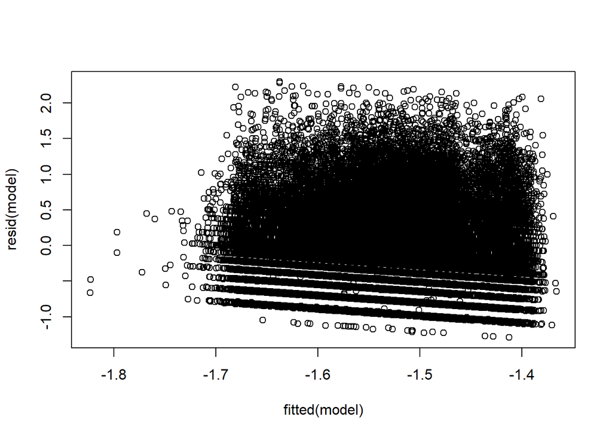

```r
# Simple plot of residuals vs. predicted values
plot(fitted(model), resid(model))
```

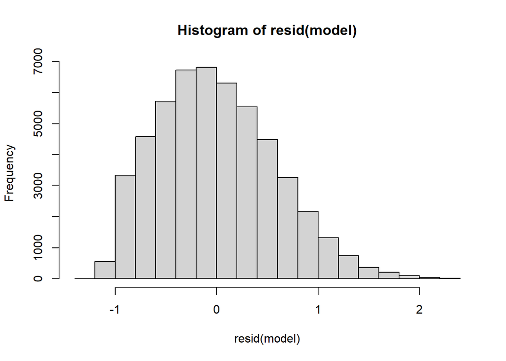

```r
# Histogram of Residuals
hist(resid(model))
```

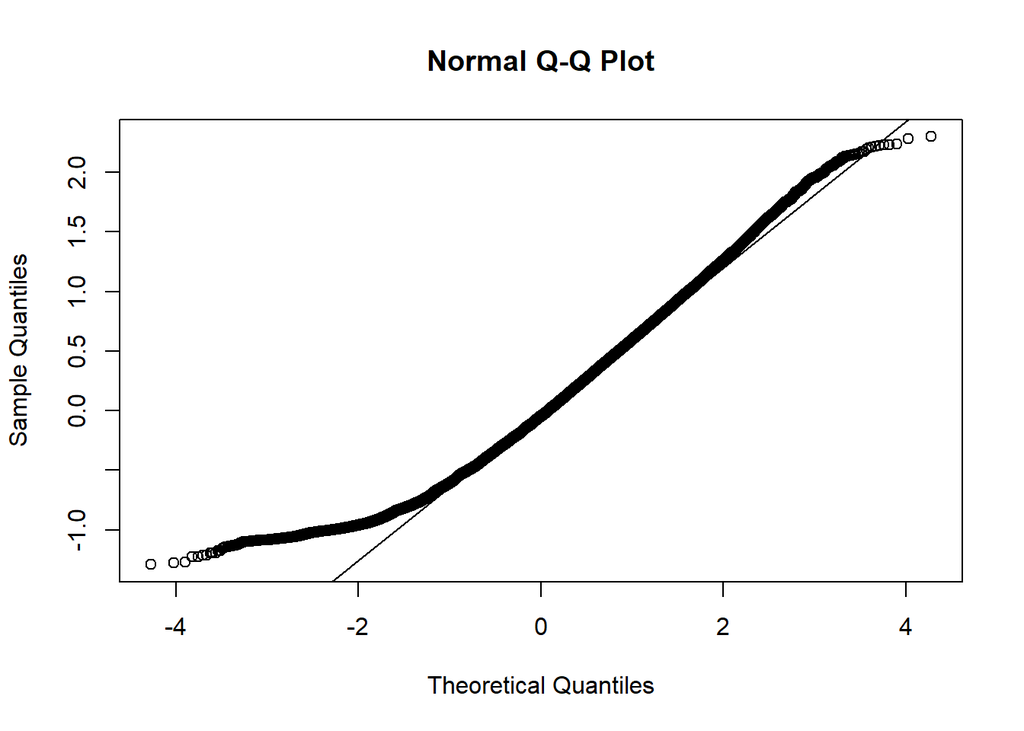

```r
# QQ plot
qqnorm(resid(model))
qqline(resid(model))
```

```r
residuals <- resid(model)

# Load lmtest package
library(lmtest)
# Breusch-Pagan test for heteroscedasticity
bp_test <- bptest(model)
print(bp_test)
```

```
##
##  studentized Breusch-Pagan test
##
## data:  model
## BP = 352.46, df = 16, p-value < 2.2e-16
```

```r
# Load the 'car' package
library(car)
# Durbin-Watson test for autocorrelation
dw_test <- durbinWatsonTest(model)
print(dw_test)
```

```
##  lag Autocorrelation D-W Statistic p-value
##    1      0.04762904      1.904709       0
##  Alternative hypothesis: rho != 0
```

```r
# Kolmogorov-Smirnov test for normality of residuals
ks_test <- ks.test(residuals, "pnorm", mean(residuals), sd(residuals))
print(ks_test)
```

```
##
##  Asymptotic one-sample Kolmogorov-Smirnov test
##
## data:  residuals
## D = 0.037052, p-value < 2.2e-16
## alternative hypothesis: two-sided
```

1. Non-normality
2. Heteroscedasticity